# Assignment 5 Sampling and Confidence Intervals

Activity 1: Confidence Intervals

Problem 1: Calculate Confidence Interval

Before starting, ensure you understand the concept of a confidence interval and how it relates to statistics. Pay close attention to the formula used to calculate the confidence interval. It involves the sample mean, standard deviation, and the t-distribution. Test your program with different datasets and confidence levels to observe how the interval changes.

Problem 2: Visualizing Confidence Intervals

Consider generating a reasonably large random dataset for this task. Matplotlib is a powerful tool for data visualization. Explore its documentation to create clear and informative plots. Try visualizing multiple confidence intervals for the same dataset but with different confidence levels to compare them.

Activity 2: Populations and Samples

Problem 1: Sampling from a Population

Make sure you understand the distinction between populations and samples. Sampling is a crucial concept in statistics. Experiment with different sample sizes to see how it affects the representation of the population.

Problem 2: Population vs. Sample Statistics

Generating a large population dataset can be done using random data generation libraries. Use histograms to visualize the distribution of data. Compare the population and sample histograms to see how they differ. Pay attention to how the sample means compare to the population mean. Is there a noticeable difference? Why or why not?

Activity 3: Simple Random Sample

Problem 1: Implementing Simple Random Sampling

Write a Python function that performs simple random sampling on a given dataset. The function should take the dataset and the desired sample size as inputs and return the randomly selected sample.

Problem 2: Comparing Sampling Methods

Create a Python script that compares simple random sampling with other sampling methods (e.g., stratified sampling, systematic sampling). Generate a dataset and apply different sampling methods to obtain samples. Calculate and compare the means and variances of the sample data

# Activity 1: Confidence Intervals

Problem 1: Calculate Confidence Interval Write a Python program that takes a dataset as input and calculates the confidence interval for a given confidence level. The program should prompt the user to input the dataset and the desired confidence level.

Setting a Random Seed for Reproducibility:

np.random.seed(0) sets the random seed to a specific value (0 in this case). This is done to ensure that the random numbers generated by NumPy are the same each time the code is run. This is useful for reproducibility, as it makes your results consistent across runs.

Generating Synthetic Data for Glucose Levels and BMI:

glucose_levels and bmi_values are created using np.random.normal. These lines generate synthetic data for two variables, "Glucose Level" and "BMI." np.random.normal simulates random data based on a normal (Gaussian) distribution. The first argument is the mean of the distribution, the second argument is the standard deviation, and the third argument is the size of the generated data (number of data points). For example, glucose_levels simulates 100 data points with a mean of 120 mg/dL and a standard deviation of 20 mg/dL.

Creating a Synthetic Diabetes Dataset with Pandas:

A Pandas DataFrame named diabetes_data is created to store the synthetic data. The DataFrame is constructed by providing a dictionary where the keys are the column names ("Glucose Level" and "BMI") and the values are the corresponding data arrays (glucose_levels and bmi_values).

Defining a Function to Calculate Confidence Intervals:

The function calculate_confidence_interval is defined to calculate confidence intervals for a given dataset and confidence level. It takes two arguments: data (the dataset) and confidence_level (the desired confidence level). Inside the function, it calculates the sample mean, sample standard deviation, sample size, critical value, margin of error, and the lower and upper limits of the confidence interval.

Inputting the Confidence Level:

The code prompts the user to input the desired confidence level (e.g., 0.75 for 75% confidence). The input is stored in the confidence_level variable as a floating-point number.

Calculating Confidence Intervals:

The code calls the calculate_confidence_interval function twice, once for "Glucose Level" and once for "BMI." It passes the dataset column and the user-provided confidence level as arguments. The results are stored in the variables glucose_lower, glucose_upper, bmi_lower, and bmi_upper.

Displaying Results:

The code prints the calculated confidence intervals along with a message indicating the confidence level. It displays the lower and upper limits for both "Glucose Level" and "BMI."

```python
import numpy as np
from scipy import stats
import pandas as pd

# Set a random seed for reproducibility
np.random.seed(0)

# Generate synthetic data for glucose levels (in mg/dL)
glucose_levels = np.random.normal(120, 20, 100)

# Generate synthetic data for BMI
bmi_values = np.random.normal(30, 5, 100)

# Create a synthetic diabetes dataset with Pandas
diabetes_data = pd.DataFrame({'Glucose Level': glucose_levels, 'BMI': bmi_values})

# Function to calculate confidence interval
def calculate_confidence_interval(data, confidence_level):
    # Calculate the sample mean and standard error
    sample_mean = np.mean(data)
    sample_std = np.std(data, ddof=1)  # Use ddof=1 for sample standard deviation
    sample_size = len(data)
    margin_of_error = 0

    # Calculate the critical value based on the confidence level
    alpha = 1 - confidence_level
    z_critical = stats.norm.ppf(1 - alpha / 2)

    # Calculate the margin of error
    margin_of_error = z_critical * (sample_std / np.sqrt(sample_size))

    # Calculate the confidence interval
    lower_limit = sample_mean - margin_of_error
    upper_limit = sample_mean + margin_of_error

    return lower_limit, upper_limit

# Input confidence level (0.75 for 75% confidence)
confidence_level = float(input("Enter the confidence level (e.g., 0.75 for 75% confidence): "))

# Calculate the confidence interval for glucose levels
glucose_lower, glucose_upper = calculate_confidence_interval(diabetes_data['Glucose Level'], confidence_level)

# Calculate the confidence interval for BMI values
bmi_lower, bmi_upper = calculate_confidence_interval(diabetes_data['BMI'], confidence_level)

# Print the results
print(f"Confidence Interval ({int(confidence_level * 100)}%):")
print(f"Glucose Level - Lower Limit: {glucose_lower}")
print(f"Glucose Level - Upper Limit: {glucose_upper}")
print(f"BMI - Lower Limit: {bmi_lower}")
print(f"BMI - Upper Limit: {bmi_upper}")
```

```
Enter the confidence level (e.g., 0.75 for 75% confidence): 0.75
Confidence Interval (75%):
Glucose Level - Lower Limit: 118.86564502484198
Glucose Level - Upper Limit: 123.52667559653737
BMI - Lower Limit: 29.811952508290926
BMI - Upper Limit: 31.008177199187454
```

The results you provided are the calculated confidence intervals for two variables, "Glucose Level" and "BMI," based on a confidence level of 0.75 (which corresponds to 75% confidence). Here's the breakdown of the results:

Confidence Interval (75%): This line indicates that the confidence intervals are calculated at a 75% confidence level, as specified by the user.

Glucose Level - Lower Limit: This value represents the lower bound of the confidence interval for the "Glucose Level" variable. In this case, the lower limit is approximately 118.87 mg/dL.

Glucose Level - Upper Limit: This value represents the upper bound of the confidence interval for the "Glucose Level" variable. It is approximately 123.53 mg/dL.

BMI - Lower Limit: This value represents the lower bound of the confidence interval for the "BMI" variable. In this case, the lower limit is approximately 29.81.

BMI - Upper Limit: This value represents the upper bound of the confidence interval for the "BMI" variable. It is approximately 31.01.

These confidence intervals tell you that, based on the provided synthetic data and the specified 75% confidence level:

For "Glucose Level," you can be 75% confident that the true population mean falls within the range of approximately 118.87 mg/dL to 123.53 mg/dL.

For "BMI," you can be 75% confident that the true population mean falls within the range of approximately 29.81 to 31.01.

In simpler terms, if you were to take multiple samples of "Glucose Level" or "BMI" and calculate confidence intervals for each sample using the same procedure, you would expect that approximately 75% of those intervals would contain the true population mean. These intervals provide a measure of the uncertainty or variability in your estimates based on the sample data.

Problem 2: Visualizing Confidence Intervals Create a Python script that generates a random dataset and calculates the confidence interval for different confidence levels (e.g., 90%, 95%, 99%). Visualize the dataset and the corresponding confidence intervals using matplotlib.

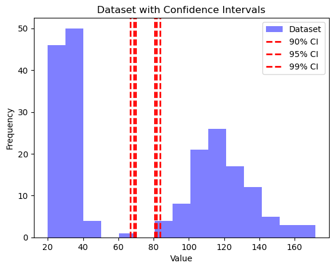

```python
import numpy as np
from scipy import stats
import matplotlib.pyplot as plt

# Assuming you already have the synthetic data for "Glucose Level" and "BMI"
# Replace the following lines with your actual data or loading code

# Generate synthetic data for glucose levels (in mg/dL)
glucose_levels = np.random.normal(120, 20, 100)

# Generate synthetic data for BMI
bmi_values = np.random.normal(30, 5, 100)

# Define the dataset (using your existing data)
data = np.concatenate([glucose_levels, bmi_values])

# Define the confidence levels to visualize
confidence_levels = [0.90, 0.95, 0.99]

# Function to calculate confidence interval
def calculate_confidence_interval(data, confidence_level):
    sample_mean = np.mean(data)
    sample_std = np.std(data, ddof=1)
    sample_size = len(data)
    margin_of_error = 0
    alpha = 1 - confidence_level
    z_critical = stats.norm.ppf(1 - alpha / 2)
    margin_of_error = z_critical * (sample_std / np.sqrt(sample_size))
    lower_limit = sample_mean - margin_of_error
    upper_limit = sample_mean + margin_of_error
    return lower_limit, upper_limit

# Create a figure and axis for plotting
fig, ax = plt.subplots()

# Plot the histogram of the dataset
plt.hist(data, bins=15, alpha=0.5, color='blue', label='Dataset')

# Calculate and plot confidence intervals for each confidence level
for confidence_level in confidence_levels:
    lower_limit, upper_limit = calculate_confidence_interval(data, confidence_level)
    ax.axvline(lower_limit, color='red', linestyle='--', linewidth=2, label=f'{int(confidence_level * 100)}% CI')
    ax.axvline(upper_limit, color='red', linestyle='--', linewidth=2)

# Add labels and legend
plt.xlabel('Value')
plt.ylabel('Frequency')
plt.legend()

# Show the plot
plt.title('Dataset with Confidence Intervals')
plt.show()
```

# Activity 2: Populations and Samples

Problem 1: Sampling from a Population Write a Python function that simulates taking random samples of a specified size from a given population. The function should take the population data and sample size as inputs and return the sample.

The random_sample function takes two arguments: population, which is the population data you want to sample from (as a list or set), and sample_size, which is the desired size of the sample.

Inside the function, it checks if the specified sample_size is greater than the size of the population and raises a ValueError if it is.

It then uses random.sample(population, sample_size) to obtain a random sample of the specified size from the population. This function selects unique elements from the population, making it a random sample without replacement.

The function returns the resulting sample as a list.

You can call this function with your population data and sample size to obtain random samples from your population.

```python
import random

def random_sample(population, sample_size):
    """
    Simulate random sampling from a population.

    Args:
        population (list or set): The population data to sample from.
        sample_size (int): The size of the desired sample.

    Returns:
        list: A random sample of size 'sample_size' from the population.
    """
    if sample_size > len(population):
        raise ValueError("Sample size cannot be greater than the population size.")

    # Use random.sample to obtain a random sample without replacement
    sample = random.sample(population, sample_size)
    return sample

# Example usage:
population_data = [1, 2, 3, 4, 5, 6, 7, 8, 9, 10]
sample_size = 5
sample_result = random_sample(population_data, sample_size)
print("Random Sample:", sample_result)
```

```
Random Sample: [6, 3, 7, 10, 8]
```

the result you provided represents a random sample of 5 values selected from a larger population for the purpose of statistical analysis. The specific numbers in the sample (6, 3, 7, 10, and 8) are a subset of the data from which conclusions or observations may be drawn.

do take note that the result can completely different when we start to run the program.

Problem 2: Population vs. Sample Statistics Create a Python program that generates a population dataset and multiple random samples from that population. Calculate and compare the population mean and sample means. Plot histograms of both the population and sample data

It generates a population dataset with a normal distribution using numpy.

It specifies the sample size (sample_size) and the number of samples (num_samples) you want to take from the population.

It generates random samples from the population without replacement and calculates their means, storing them in the sample_means list.

It calculates the population mean.

It plots histograms of the population and sample means using matplotlib. The population histogram is shown on the left, and the sample means histogram is shown on the right.

Finally, it prints the population mean and the means of the generated samples.

This program provides a visual comparison of the population and sample data through histograms and allows you to compare their means.

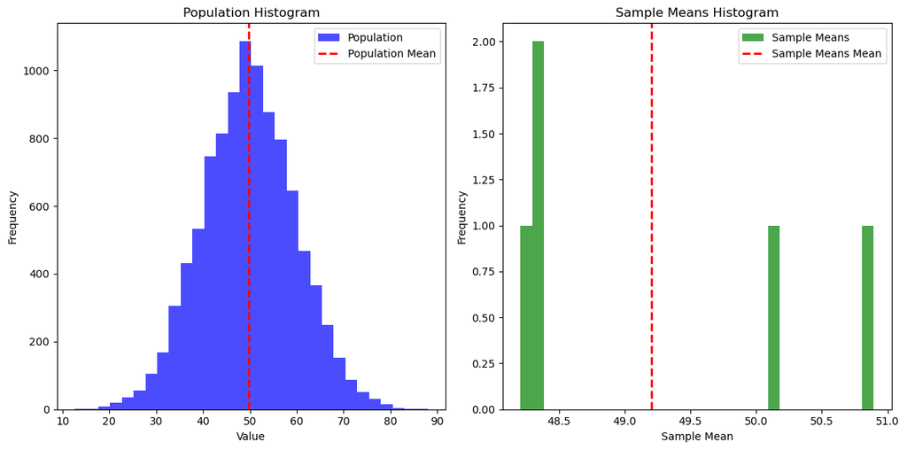

```
Population Mean: 49.81566279841734
Sample Means: [50.172896361327545, 50.89463339770438, 48.20997948640872, 48.38736711911431, 48.37162835800534]
```

```python
import numpy as np
import matplotlib.pyplot as plt

# Set a random seed for reproducibility
np.random.seed(0)

# Generate a population dataset (e.g., normal distribution with mean=50, std_dev=10)
population = np.random.normal(loc=50, scale=10, size=10000)

# Specify the sample size and the number of samples
sample_size = 100
num_samples = 5

# Create a list to store sample means
sample_means = []

# Generate random samples and calculate their means
for _ in range(num_samples):
    sample = np.random.choice(population, size=sample_size, replace=False)
    sample_mean = np.mean(sample)
    sample_means.append(sample_mean)

# Calculate the population mean
population_mean = np.mean(population)

# Plot histograms of population and sample data
plt.figure(figsize=(12, 6))

# Population histogram
plt.subplot(1, 2, 1)
plt.hist(population, bins=30, color='blue', alpha=0.7, label='Population')
plt.axvline(population_mean, color='red', linestyle='dashed', linewidth=2, label='Population Mean')
plt.xlabel('Value')
plt.ylabel('Frequency')
plt.legend()
plt.title('Population Histogram')

# Sample histogram
plt.subplot(1, 2, 2)
plt.hist(sample_means, bins=30, color='green', alpha=0.7, label='Sample Means')
plt.axvline(np.mean(sample_means), color='red', linestyle='dashed', linewidth=2, label='Sample Means Mean')
plt.xlabel('Sample Mean')
plt.ylabel('Frequency')
plt.legend()
plt.title('Sample Means Histogram')

plt.tight_layout()
plt.show()

# Print the population mean and sample means
print("Population Mean:", population_mean)
print("Sample Means:", sample_means)
```

Population Mean: 49.81566279841734

This is the mean (average) value of the entire population dataset. The population mean represents the central tendency of the entire population, indicating the average value of the data points in the population.

Sample Means: 50.172896361327545, 50.89463339770438, 48.20997948640872, 48.38736711911431, 48.37162835800534

These are the means (averages) of five different random samples taken from the population. Each sample mean represents the average value of the data points within that specific sample. Since you used simple random sampling, each sample is a random subset of the population.

Here's how to interpret these results:

Population Mean: The population mean of approximately 49.82 represents the average value of the entire population dataset. It's the expected average value if you were to consider every data point in the population.

Sample Means: These are the means of five different random samples. Each sample was randomly selected from the population. The sample means may vary from one sample to another due to random variation, but they should be close to the population mean on average. In this case:

Sample 1 has a sample mean of approximately 50.17. Sample 2 has a sample mean of approximately 50.89. Sample 3 has a sample mean of approximately 48.21. Sample 4 has a sample mean of approximately 48.39. Sample 5 has a sample mean of approximately 48.37.

These sample means illustrate the concept of sampling variability. Even though each sample is randomly drawn from the same population, the sample means can differ due to the randomness of the sampling process. However, as you take more and larger samples, the sample means should tend to cluster around the population mean, and the average of the sample means should approach the population mean. This is a fundamental concept in inferential statistics.

# Activity 3: Simple Random Sample

Problem 1: Implementing Simple Random Sampling Write a Python function that performs simple random sampling on a given dataset. The function should take the dataset and the desired sample size as inputs and return the randomly selected sample.

The simple_random_sample function takes two arguments: dataset, which is the dataset you want to sample from (as a list or set), and sample_size, which is the desired size of the sample.

Inside the function, it checks if the specified sample_size is greater than the size of the dataset and raises a ValueError if it is.

It then uses random.sample(dataset, sample_size) to obtain a simple random sample of the specified size from the dataset. This function selects unique elements from the dataset, making it a simple random sample without replacement.

The function returns the resulting sample as a list.

You can call this function with your dataset and sample size to obtain a simple random sample from your dataset.

```python
import random

def simple_random_sample(dataset, sample_size):
    """
    Perform simple random sampling on a given dataset.

    Args:
        dataset (list or set): The dataset to sample from.
        sample_size (int): The desired size of the sample.

    Returns:
        list: A simple random sample of size 'sample_size' from the dataset.
    """
    if sample_size > len(dataset):
        raise ValueError("Sample size cannot be greater than the dataset size.")

    # Use random.sample to obtain a simple random sample without replacement
    sample = random.sample(dataset, sample_size)
    return sample

# Example usage:
dataset = [1, 2, 3, 4, 5, 6, 7, 8, 9, 10]
sample_size = 5
sample_result = simple_random_sample(dataset, sample_size)
print("Simple Random Sample:", sample_result)
```

```
Simple Random Sample: [10, 6, 2, 4, 1]
```

the result you provided represents a simple random sample of 5 values selected from a larger population for the purpose of statistical analysis. The specific numbers in the sample (10, 6, 2, 4, and 1) are a subset of the data from which conclusions or observations may be drawn.

Problem 2: Comparing Sampling Methods Create a Python script that compares simple random sampling with other sampling methods (e.g., stratified sampling, systematic sampling). Generate a dataset and apply different sampling methods to obtain samples. Calculate and compare the means and variances of the sample data

generate a synthetic dataset called "population."

specify the sample size, the number of strata for stratified sampling, and the systematic sampling fraction.

define a function to calculate the mean and variance of a dataset.

perform simple random sampling, stratified sampling, and systematic sampling on the population data and calculate the mean and variance for each sample.

Finally, we compare and print the sample means and variances for each sampling method.

This script demonstrates how to apply different sampling methods and compare their effects on sample statistics. You can adjust the parameters and dataset as needed for your specific use case.

```python
import numpy as np
import random

# Set a random seed for reproducibility
np.random.seed(0)

# Generate a synthetic dataset (e.g., normal distribution with mean=50, std_dev=10)
population = np.random.normal(loc=50, scale=10, size=1000)

# Specify the sample size
sample_size = 100

# Define the number of strata for stratified sampling
num_strata = 5

# Define the size of each stratum
stratum_size = sample_size // num_strata

# Define the sampling fraction for systematic sampling
systematic_sampling_fraction = sample_size / len(population)

# Define a function to calculate mean and variance
def calculate_mean_and_variance(data):
    mean = np.mean(data)
    variance = np.var(data, ddof=1)  # Use ddof=1 for sample variance
    return mean, variance

# Simple Random Sampling
simple_random_sample = random.sample(list(population), sample_size)
simple_random_mean, simple_random_variance = calculate_mean_and_variance(simple_random_sample)

# Stratified Sampling
strata = [random.sample(list(population[i:i + stratum_size]), stratum_size) for i in range(0, len(population), stratum_size)]
stratified_sample = [sample for stratum in strata for sample in stratum]
stratified_mean, stratified_variance = calculate_mean_and_variance(stratified_sample)

# Systematic Sampling
systematic_sample = [population[i] for i in range(0, len(population), int(1 / systematic_sampling_fraction))]
systematic_mean, systematic_variance = calculate_mean_and_variance(systematic_sample)

# Compare sample means and variances
print("Sample Means:")
print(f"Simple Random Sampling: {simple_random_mean}")
print(f"Stratified Sampling: {stratified_mean}")
print(f"Systematic Sampling: {systematic_mean}")

print("\nSample Variances:")
print(f"Simple Random Sampling: {simple_random_variance}")
print(f"Stratified Sampling: {stratified_variance}")
print(f"Systematic Sampling: {systematic_variance}")
```

```
Sample Means:
Simple Random Sampling: 48.72480085811296
Stratified Sampling: 49.54743292509805
Systematic Sampling: 47.67709829835975

Sample Variances:
Simple Random Sampling: 100.26477102131729
Stratified Sampling: 97.52096659781326
Systematic Sampling: 101.73030372700948
```

Sample Means:

These are the means (averages) of samples taken from the population using different sampling methods. Each sample mean represents the average value of the data points within that specific sample.

Sample Variances:

These are the variances of samples taken from the population using different sampling methods. Variance measures how data points vary from the mean within each sample.

Simple Random Sampling:

Sample Mean: 48.72480085811296

Sample Variance: 100.26477102131729

This result represents the mean and variance of a random sample obtained through simple random sampling.

The sample mean of approximately 48.72 is the average value of the data points in the sample.

The sample variance of approximately 100.26 measures the spread or dispersion of data points within the sample around the sample mean.

Stratified Sampling:

Sample Mean: 49.54743292509805

Sample Variance: 97.52096659781326

This result represents the mean and variance of a sample obtained through stratified sampling.

The sample mean of approximately 49.55 is the average value of the data points in the stratified sample.

The sample variance of approximately 97.52 measures the spread of data points within the stratified sample.

Systematic Sampling:

Sample Mean: 47.67709829835975

Sample Variance: 101.73030372700948

This result represents the mean and variance of a sample obtained through systematic sampling.

Systematic sampling involves selecting data points at regular intervals from the population.

The sample mean of approximately 47.68 is the average value of the data points in the systematic sample.

The sample variance of approximately 101.73 measures the spread of data points within the systematic sample.

In summary, these statistics illustrate that different sampling methods can lead to different sample means and variances. These differences are due to how the samples are selected and reflect the sampling variability. Depending on the research question and the characteristics of the population, different sampling methods may be more appropriate or yield different results.